# **Task 1 - Gradient Descent Using Numpy - MS4H20**

This notebook covers each section of task 1 for the MS4H20 coursework. First, the relevant libraries are imported below.

```python
# Import Libraries
from IPython.display import display
from PIL import Image as PILImage
import numpy as np
```

## Part 1 - Question 1

"Using the rules of differentiation, differentiate the following (showing your workings, by-hand): $f(r)=(6r-12)^2$"

For this question I have used the chain rule and power rule to differentiate the equation, with the final answer being $12(6r - 12)$ or $72r - 144$

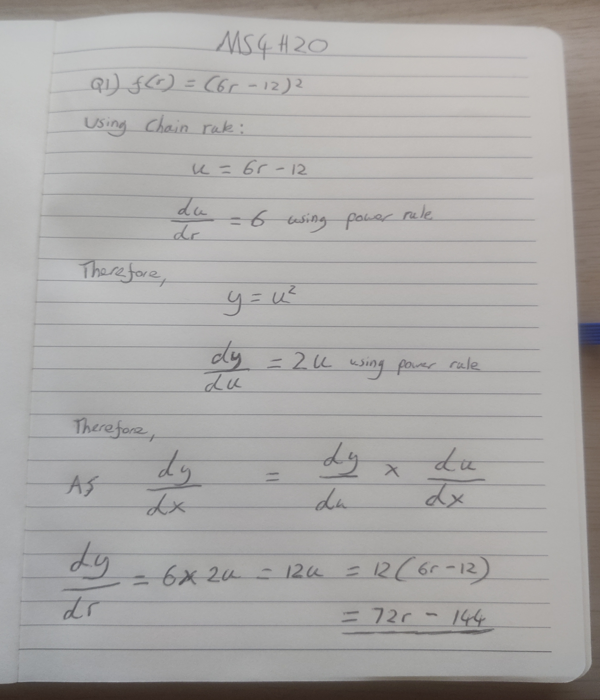

```python
# Open the picture
img = PILImage.open('C:/Users/hagu2/OneDrive/Documents/Advanced Skills Data/Q1.jpg')
# Resize the picture
resized_img = img.resize((600, 700))
# Display the resized picture
display(resized_img)
```

## Part 1 - Question 2

"Using the rules of differentiation, differentiate the following (showing your workings, by-hand): $f(s)=(36-s^2 )^2-(4s-24)^2$"

For this question my working is split down the middle, using chain rule on $(36 - s^2)^2$ on the left, and $(4s - 24)^2$ on the right. Then the sum rule is used to get a final answer of $4s^3 - 176s + 192$

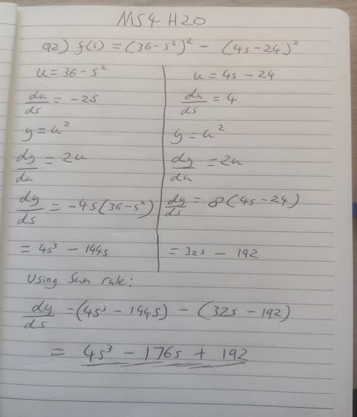

```python
# Open the picture
img = PILImage.open('C:/Users/hagu2/OneDrive/Documents/Advanced Skills Data/Q2.jpg')
# Resize the picture
resized_img = img.resize((600, 700))
# Display the resized picture
display(resized_img)
```

## Part 1 - Question 3

"Using the rules of differentiation, differentiate the following (showing your workings, by-hand): $f(t)= 2(t^2/t-5)^2$"

For this question the chain rule and power rule have been used to get the final answer $4t - 20$

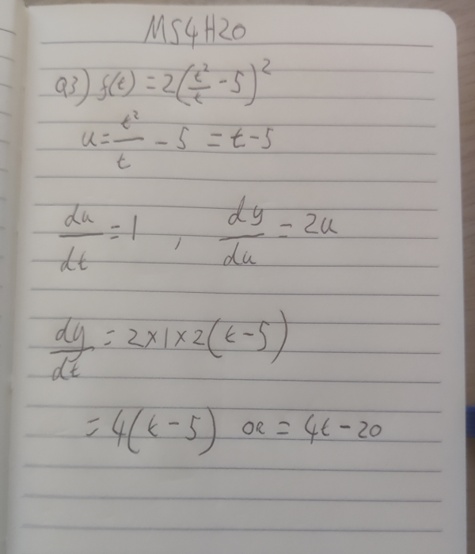

```python
# Open the picture using Pillow
img = PILImage.open('C:/Users/hagu2/OneDrive/Documents/Advanced Skills Data/Q3.jpg')
# Resize the image
resized_img = img.resize((600, 700))
# Display the resized image in the notebook
display(resized_img)
```

## Part 2a

"Using your answers, create a NumPy Program which applies the gradient descent algorithm to minimise the given error function. Initialise the algorithm with the following values: $r=0,s=0,t=0$."

Here I have created a class that incorporates the equation $y=f(r,s,t)= (6r-12)^2+ (36-s^2 )^2-(4s-24)^2+ 2(t^2/t-5)^2$ and performs gradient descent to find the values of r, s, and t that minimise the error $E = y^2$

The class contains documentation for each section, outlining how it carries out this task. It has the parameters r, s, t, as well as learning rate and a convergence threshold that will stop the gradient descent once the change in error is small enough. These all have default values but can be customised when using the class

The class performs gradient calculations for r, s, and t, then updates the values using the learning rate and the calculated gradient value. The error is calculated each time, and the model runs until either the convergence threshold is reached, or the maximum number of iterations is reached. Here the maximum iterations is set to 1000.

Computational efficiency has been considered when creating this class by incorporating customisable values of learning rate and convergence threshold. A higher convergence threshold would stop the descent at a fewer number of iterations, and speed up the computational process. Therefore an appropriate learning rate and conbergence threshold can be selected depending on the specific problem, this will be further mentioned when using the class to find the values of r, s, and t where the error is 0.

```python
class Model:
    """
    A class representing a mathematical model of the equation:
    y = ((6 * r - 12) ** 2) + (((36 - s ** 2) ** 2) - ((4 * s) - 24) ** 2) + 2 * ((t - 5)) ** 2
    with three parameters (r, s, t).
    The model calculates a value 'y' based on the parameters and provides
    functions for gradient descent.

    Parameters:
        r (float): The first parameter of the model (default: 0).
        s (float): The second parameter of the model (default: 0).
        t (float): The third parameter of the model (default: 0).
        learning_rate (float): The learning rate used in gradient descent (default: 0.002).
        convergence_threshold (float): The convergence threshold that will stop gradient descent once changes in error become small enough. (default: 1e-5).
    """

    def __init__(self, r: float = 0, s: float = 0, t: float = 0,
                 learning_rate: float = 0.002, convergence_threshold: float = 1e-5):
        """
        Initializes a new instance of the Model class.

        Args:
            r (float): The initial value of parameter 'r'.
            s (float): The initial value of parameter 's'.
            t (float): The initial value of parameter 't'.
            learning_rate (float): The learning rate used for gradient descent.
            convergence_threshold (float): The convergence threshold that will stop gradient descent once changes in error become small enough.
        """
        self.r = r
        self.s = s
        self.t = t
        self.learning_rate = learning_rate
        self.convergence_threshold = convergence_threshold

    def calculate(self) -> float:
        """
        Calculates the value of y based on the value of r, s, and t.

        Returns:
            float: The calculated value of y.
        """
        y = ((6 * self.r - 12) ** 2) + (((36 - self.s ** 2) ** 2) - ((4 * self.s) - 24) ** 2) + 2 * ((self.t - 5)) ** 2
        return y

    def error(self, y):
        """
        Calculates the error E given the value of y.

        Args:
            y (float): The model's value of y.

        Returns:
            float: The calculated error E.
        """
        E = y ** 2
        return E

    def gradient_calculation_r(self):
        """
        Calculates the partial derivative of the model function with respect to r: (df/dr).

        Returns:
            float: The calculated value of df/dr.
        """
        df_dr = 72 * self.r - 144
        return df_dr

    def gradient_calculation_s(self):
        """
        Calculates the partial derivative of the model function with respect to s: (df/ds).

        Returns:
            float: The calculated value of df/ds.
        """
        df_ds = ((4 * self.s) ** 3) - (176 * self.s) + 192
        return df_ds

    def gradient_calculation_t(self):
        """
        Calculates the partial derivative of the model function with respect to t: (df/dt).

        Returns:
            float: The calculated value of df/dt.
        """
        df_dt = 4 * self.t - 20
        return df_dt

    def update_value_r(self, df_dr):
        """
        Updates the value r using the learning rate and partial derivative.

        Args:
            df_dr (float): The gradient of the model function with respect to r: (df/dr).

        Returns:
            float: The updated value of r.
        """
        r_new = self.r - self.learning_rate * df_dr
        return r_new

    def update_value_s(self, df_ds):
        """
        Updates the value s using the learning rate and partial derivative.

        Args:
            df_ds (float): The gradient of the model function with respect to s: (df/ds).

        Returns:
            float: The updated value of s.
        """
        s_new = self.s - self.learning_rate * df_ds
        return s_new

    def update_value_t(self, df_dt):
        """
        Updates the value t using the learning rate and partial derivative.

        Args:
            df_dt (float): The gradient of the model function with respect to t: (df/dt).

        Returns:
            float: The updated value of t.
        """
        t_new = self.t - self.learning_rate * df_dt
        return t_new

    def gradient_descent(self):
        """
        Performs gradient descent to minimise the model error.

        The model continues until the change in error between  iterations becomes smaller than the convergence threshold or reaches a fixed maximum number of iterations (1000).
        """
        prev_error = float('inf')  # Initialize the previous error with a large value

        for i in range(1, 1000):  # Use a fixed maximum number of iterations

            # Calculate the current error and check for convergence
            y = self.calculate()
            E = self.error(y)
            if abs(E - prev_error) < self.convergence_threshold:
                print(f"Convergence reached after iteration {i}")
                break

            print(f"Iteration: {i} | r = {self.r} | s = {self.s} | t = {self.t} | Error = {E}")

            # Calculate the gradients
            df_dr = self.gradient_calculation_r()
            df_ds = self.gradient_calculation_s()
            df_dt = self.gradient_calculation_t()

            # Update the weights (r, s, t) using the learning rate and gradients
            self.r = self.update_value_r(df_dr)
            self.s = self.update_value_s(df_ds)
            self.t = self.update_value_t(df_dt)

            prev_error = E  # Update the previous error for the next iteration

        print(f"The final r = {self.r}, the final s = {self.s}, the final t = {self.t}, and the final error is {E}")
```

It is interesting to note that the final error is 721, which is higher than the error after only the 25th iteration with an error of 71. This could be as a result of local minima impacting the gradient descent, as well as how very small differences in the values of the parameters can lead to large errors in this equation.

Another interesting thing to note is that there are multiple values of s that can lead to a value of y = 0. These values are s = -2, s = 6, and s = -10. It is possible that the range of different possible values of s also has an impact on the gradient descent, and the model could optimise any one of those three possible values. Here though, the gradient descent otpimisation consistently goes towards a value of s = -2.

Rounding to the nearest integer, the results show values of $r = 2 , s = -2 , t = 5$

```python
# Using the Model class to perform gradient descent
results = Model(0, 0, 0, 0.003, 1e-1)
results.gradient_descent()
```

```
Iteration: 1 | r = 0 | s = 0 | t = 0 | Error = 835396
Iteration: 2 | r = 0.432 | s = -0.5760000000000001 | t = 0.06 | Error = 515006.38208251155
Iteration: 3 | r = 0.770688 | s = -1.419436228608 | t = 0.11928 | Error = 141580.3718464151
Iteration: 4 | r = 1.036219392 | s = -2.1958017916348833 | t = 0.17784864 | Error = 515.1506302152337
Iteration: 5 | r = 1.244396003328 | s = -1.898450750692362 | t = 0.23571445632000002 | Error = 13753.552341289427
Iteration: 6 | r = 1.407606466609152 | s = -2.1631235680624172 | t = 0.29288588284416 | Error = 797.4692980344051
Iteration: 7 | r = 1.535563469821575 | s = -1.9379288034486852 | t = 0.3493712522500301 | Error = 6815.148864921423
Iteration: 8 | r = 1.6358817603401148 | s = -2.1397747011959374 | t = 0.40517879722302974 | Error = 665.3854260281408
Iteration: 9 | r = 1.71453130010665 | s = -1.964503937221512 | t = 0.4603166516563534 | Error = 3874.336109494325
Iteration: 10 | r = 1.7761925392836135 | s = -2.122102045737743 | t = 0.5147928518364772 | Error = 458.7407349600341
Iteration: 11 | r = 1.824534950798353 | s = -1.983724230274166 | t = 0.5686153376144394 | Error = 2371.5841753313885
Iteration: 12 | r = 1.8624354014259088 | s = -2.1083256595244877 | t = 0.6217919535630662 | Error = 295.3159582862018
Iteration: 13 | r = 1.8921493547179125 | s = -1.9981771442840095 | t = 0.6743304501203093 | Error = 1503.4747970078224
Iteration: 14 | r = 1.9154450940988434 | s = -2.0974107093295395 | t = 0.7262384847188657 | Error = 187.32374889780502
Iteration: 15 | r = 1.9337089537734933 | s = -2.0093006701041745 | t = 0.7775236229022393 | Error = 964.0616885678772
Iteration: 16 | r = 1.9480278197584187 | s = -2.0886828746902575 | t = 0.8281933394274125 | Error = 120.9592276817326
Iteration: 17 | r = 1.9592538106906001 | s = -2.0179880975185456 | t = 0.8782550193542835 | Error = 615.3755696158978
Iteration: 18 | r = 1.9680549875814306 | s = -2.081667364257937 | t = 0.9277159591220321 | Error = 81.5843985238778
Iteration: 19 | r = 1.9749551102638416 | s = -2.0248382145077284 | t = 0.9765833676125677 | Error = 385.8009691516229
Iteration: 20 | r = 1.9803648064468518 | s = -2.0760118920999577 | t = 1.024864367201217 | Error = 58.78343401306266
Iteration: 21 | r = 1.9846060082543318 | s = -2.030274414250321 | t = 1.0725659947948023 | Error = 234.06157301384326
Iteration: 22 | r = 1.9879311104713961 | s = -2.0714458727179506 | t = 1.1196952028572646 | Error = 46.03972192469802
Iteration: 23 | r = 1.9905379906095746 | s = -2.0346075824053167 | t = 1.1662588604229776 | Error = 134.62878117443736
Iteration: 24 | r = 1.9925817846379066 | s = -2.06775682500701 | t = 1.2122637540979018 | Error = 39.525553403414186
Iteration: 25 | r = 1.9941841191561187 | s = -2.038072160805315 | t = 1.257716589048727 | Error = 70.98598110135305
Iteration: 26 | r = 1.995440349418397 | s = -2.0647755958362115 | t = 1.3026239899801422 | Error = 37.082279957623186
Iteration: 27 | r = 1.9964252339440232 | s = -2.0408483026139095 | t = 1.3469925021003806 | Error = 32.13546750869118
Iteration: 28 | r = 1.9971973834121142 | s = -2.0623664221106712 | t = 1.390828592075176 | Error = 37.52867986551835
Iteration: 29 | r = 1.9978027485950975 | s = -2.0430762960113444 | t = 1.4341386489702739 | Error = 10.612812452078924
Iteration: 30 | r = 1.9982773548985564 | s = -2.06041983404553 | t = 1.4769289851826306 | Error = 40.229173525443805
Iteration: 31 | r = 1.9986494462404683 | s = -2.0448664191963215 | t = 1.5192058373604391 | Error = 1.2818992654738477
Iteration: 32 | r = 1.9989411658525271 | s = -2.058847347151881 | t = 1.5609753673121138 | Error = 44.83656177901618
Iteration: 33 | r = 1.9991698740283812 | s = -2.046305943301037 | t = 1.6022436629043684 | Error = 0.5708624029115599
Iteration: 34 | r = 1.999349181238251 | s = -2.057577359188728 | t = 1.643016738949516 | Error = 51.144684008757125
Iteration: 35 | r = 1.9994897580907887 | s = -2.0474642653090123 | t = 1.6833005380821218 | Error = 5.973263686861589
Iteration: 36 | r = 1.9995999703431784 | s = -2.0565519088595963 | t = 1.7231009316251362 | Error = 59.00788558204906
Iteration: 37 | r = 1.9996863767490518 | s = -2.048396761270742 | t = 1.7624237204456346 | Error = 15.715907041683536
Iteration: 38 | r = 1.9997541193712567 | s = -2.0557240807123836 | t = 1.801274635800287 | Error = 68.29991752260459
Iteration: 39 | r = 1.9998072295870652 | s = -2.0491477315532007 | t = 1.8396593401706836 | Error = 28.53447947905791
Iteration: 40 | r = 1.9998488679962592 | s = -2.055055911337544 | t = 1.8775834280886354 | Error = 78.89533945118616
```

[output cut: 216 more lines]

```
Iteration: 257 | r = 1.9999999999999996 | s = -2.0522666387823354 | t = 4.772622326371463 | Error = 719.8920122759713
Iteration: 258 | r = 1.9999999999999996 | s = -2.0522666387827204 | t = 4.775350858455006 | Error = 720.0243875679046
Iteration: 259 | r = 1.9999999999999996 | s = -2.052266638782375 | t = 4.778046648153546 | Error = 720.1536166323733
Iteration: 260 | r = 1.9999999999999996 | s = -2.052266638782685 | t = 4.780710088375703 | Error = 720.2797740105785
Iteration: 261 | r = 1.9999999999999996 | s = -2.052266638782407 | t = 4.783341567315195 | Error = 720.4029324191566
Iteration: 262 | r = 1.9999999999999996 | s = -2.0522666387826565 | t = 4.785941468507413 | Error = 720.5231629298687
Iteration: 263 | r = 1.9999999999999996 | s = -2.052266638782432 | t = 4.788510170885323 | Error = 720.6405348843724
Iteration: 264 | r = 1.9999999999999996 | s = -2.052266638782634 | t = 4.7910480488347 | Error = 720.7551160449092
Iteration: 265 | r = 1.9999999999999996 | s = -2.0522666387824526 | t = 4.793555472248683 | Error = 720.8669725318707
Iteration: 266 | r = 1.9999999999999996 | s = -2.052266638782615 | t = 4.7960328065816995 | Error = 720.9761689508562
Iteration: 267 | r = 1.9999999999999996 | s = -2.0522666387824695 | t = 4.798480412902719 | Error = 721.082768347878
Iteration: 268 | r = 1.9999999999999996 | s = -2.0522666387826005 | t = 4.800898647947887 | Error = 721.1868323175746
Iteration: 269 | r = 1.9999999999999996 | s = -2.0522666387824824 | t = 4.803287864172512 | Error = 721.2884209723135
Convergence reached after iteration 270
The final r = 1.9999999999999996, the final s = -2.0522666387825885, the final t = 4.805648409802442, and the final error is 721.387593034849
```

Before moving on to proving those values by hand, I have used the calculate function within the Model class to show the range of different possibilities that lead to a value of y = 0 However, as the gradient descent optimisation resulted in a value of s = -2, that is what will be used for the following question.

```python
check1 = Model(2, -2, 5)
print(check1.calculate())
check2 = Model(2, 6, 5)
print(check2.calculate())
check3 = Model(2, -10, 5)
print(check3.calculate())
```

```
0
0
0
```

## Part 2b

Determine the true (non-approximated) values of r,s & t such that E=y=0, verifying your answers mathematically (show your workings, by-hand).

Here, the values of $r = 2, s = -2, t = 5$ have been subbed in to each section independently to verify that $y = 0$ at these values.

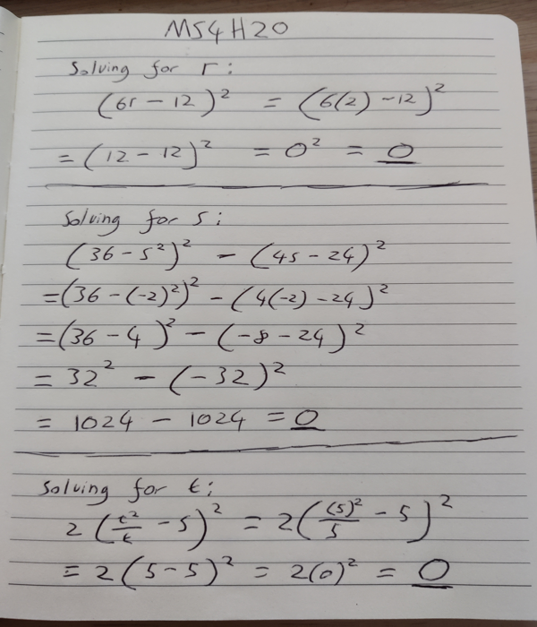

```python
# Open the picture using Pillow
img = PILImage.open('C:/Users/hagu2/OneDrive/Documents/Advanced Skills Data/Q4.jpg')
# Resize the image
resized_img = img.resize((600, 700))
# Display the resized image in the notebook
display(resized_img)
```